# data_607-week_05

Nicholas Chung

09/29/2019

# 1. question

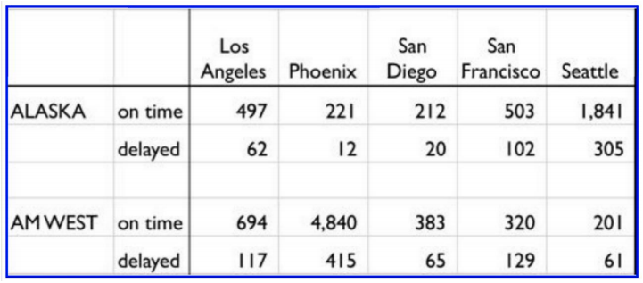

source: Numbersense, Kaiser Fung, McGraw HIll, 2013

##### The chart above describes arrival delays for two airlines across five destinations. Your task is to:

##### (1) Create a .CSV file (or optionally, a MySQL database!) that includes all of the information above. You’re encouraged to use a “wide” structure similar to how the information appears above, so that you can practice tidying and transformations as described below.

##### (2) Read the information from your .CSV file into R, and use tidyr and dplyr as needed to tidy and transform your data.

##### (3) Perform analysis to compare the arrival delays for the two airlines.

##### (4) Your code should be in an R Markdown file, posted to rpubs.com, and should include narrative descriptions of your data cleanup work, analysis, and conclusions. Please include in your homework submission:

- The URL to the .Rmd file in your GitHub repository. and
- The URL for your rpubs.com web page.

# 2. methodology

##### 1. build original table in csv

##### 2. load and melt

# 2-1. data loading

```r
# read csv into R
raw_data <- read.csv("airline_delays.csv", sep = ",")#, check.names = FALSE)
raw_data
```

```
##         X     X.1 los.angeles phoenix san.diego san.francisco seattle
## 1  alaska on time         497     221       212           503    1841
## 2  alaska delayed          62      12        20           102     305
## 3                          NA      NA        NA            NA      NA
## 4 am west on time         694    4840       383           320     201
## 5 am west delayed         117     415        65           129      61
```

# 2-2. observations

##### this dataset contains four variables:

- airline, stored in the rows
- status, stored in the rows
- city, spread across the column names,
- count, stored in the cell values

```r
# modify column names for easier reference and drop row with blank values
headers.raw_data <- raw_data %>%
  rename(airline = 1, status = 2) %>%
  drop_na()
headers.raw_data
```

```
##   airline  status los.angeles phoenix san.diego san.francisco seattle
## 1  alaska on time         497     221       212           503    1841
## 2  alaska delayed          62      12        20           102     305
## 4 am west on time         694    4840       383           320     201
## 5 am west delayed         117     415        65           129      61
```

# 2-3. tidying

##### data cleaning requires that:

- the city names are gathered into a column against counts
- the status are spread against count
- city values have spaces instead of periods
- descriptive calculations are available for analysis and visualization

```r
# melt city and count
molten.raw_data <- headers.raw_data %>%
  pivot_longer(-c(airline, status), names_to = "city", values_to = "count")
head(molten.raw_data)
```

```
## # A tibble: 6 x 4
##   airline status  city          count
##   <fct>   <fct>   <chr>         <int>
## 1 alaska  on time los.angeles     497
## 2 alaska  on time phoenix         221
## 3 alaska  on time san.diego       212
## 4 alaska  on time san.francisco   503
## 5 alaska  on time seattle        1841
## 6 alaska  delayed los.angeles      62
```

```r
# cast status and count
casted.raw_data <- molten.raw_data %>%
  pivot_wider(names_from = "status", values_from = "count")
head(casted.raw_data)
```

```
## # A tibble: 6 x 4
##   airline city          `on time` delayed
##   <fct>   <chr>             <int>   <int>
## 1 alaska  los.angeles         497      62
## 2 alaska  phoenix             221      12
## 3 alaska  san.diego           212      20
## 4 alaska  san.francisco       503     102
## 5 alaska  seattle            1841     305
## 6 am west los.angeles         694     117
```

```r
# replace period with spaces for values in column "city"
casted.raw_data$city <- str_replace_all(casted.raw_data$city, "\\.", " ")
head(casted.raw_data)
```

```
## # A tibble: 6 x 4
##   airline city          `on time` delayed
##   <fct>   <chr>             <int>   <int>
## 1 alaska  los angeles         497      62
## 2 alaska  phoenix             221      12
## 3 alaska  san diego           212      20
## 4 alaska  san francisco       503     102
## 5 alaska  seattle            1841     305
## 6 am west los angeles         694     117
```

```r
# new column for total flights
casted.raw_data$flights <- casted.raw_data$`on time` + casted.raw_data$delayed

# new column for percentage of flights that are delayed
casted.raw_data$delayed_rate <- casted.raw_data$delayed / casted.raw_data$flights
casted.raw_data
```

```
## # A tibble: 10 x 6
##    airline city          `on time` delayed flights delayed_rate
##    <fct>   <chr>             <int>   <int>   <int>        <dbl>
##  1 alaska  los angeles         497      62     559       0.111
##  2 alaska  phoenix             221      12     233       0.0515
##  3 alaska  san diego           212      20     232       0.0862
##  4 alaska  san francisco       503     102     605       0.169
##  5 alaska  seattle            1841     305    2146       0.142
##  6 am west los angeles         694     117     811       0.144
##  7 am west phoenix            4840     415    5255       0.0790
##  8 am west san diego           383      65     448       0.145
##  9 am west san francisco       320     129     449       0.287
## 10 am west seattle             201      61     262       0.233
```